# 2015 Flight Delays and Cancellations

Shruti Savadi

1/15/2020

```r
library(tidyverse)
library(hms)
airlines <- read_csv("airlines.csv")
airports  <- read_csv("airports.csv")
flights <- read_csv("flights.zip")
head(flights)
```

```
## # A tibble: 6 x 31
##    YEAR MONTH   DAY DAY_OF_WEEK AIRLINE FLIGHT_NUMBER TAIL_NUMBER ORIGIN_AIRPORT
##   <dbl> <dbl> <dbl>       <dbl> <chr>           <dbl> <chr>       <chr>
## 1  2015     1     1           4 AS                 98 N407AS      ANC
## 2  2015     1     1           4 AA               2336 N3KUAA      LAX
## 3  2015     1     1           4 US                840 N171US      SFO
## 4  2015     1     1           4 AA                258 N3HYAA      LAX
## 5  2015     1     1           4 AS                135 N527AS      SEA
## 6  2015     1     1           4 DL                806 N3730B      SFO
## # ... with 23 more variables: DESTINATION_AIRPORT <chr>,
## #   SCHEDULED_DEPARTURE <chr>, DEPARTURE_TIME <chr>, DEPARTURE_DELAY <dbl>,
## #   TAXI_OUT <dbl>, WHEELS_OFF <chr>, SCHEDULED_TIME <dbl>, ELAPSED_TIME <dbl>,
## #   AIR_TIME <dbl>, DISTANCE <dbl>, WHEELS_ON <chr>, TAXI_IN <dbl>,
## #   SCHEDULED_ARRIVAL <chr>, ARRIVAL_TIME <chr>, ARRIVAL_DELAY <dbl>,
## #   DIVERTED <dbl>, CANCELLED <dbl>, CANCELLATION_REASON <chr>,
## #   AIR_SYSTEM_DELAY <dbl>, SECURITY_DELAY <dbl>, AIRLINE_DELAY <dbl>,
## #   LATE_AIRCRAFT_DELAY <dbl>, WEATHER_DELAY <dbl>
```

```r
subflts <- flights %>% filter(AIRLINE=="DL" & MONTH==1 & DAY==1)
```

#Q1 You want to supplement subflts dataset with detailed airport information from airports dataset. How many variables do you have after you merge subflts with airports using the following code involving left_join? Note: The airport code in airports dataset is IATA_CODE. Hint: Since you have two variables denoting the airport, ORIGIN_AIRPORT and DESTINATION_AIRPORT, you have to join twice.

```r
subflts %>%
  left_join(airports, by=c("ORIGIN_AIRPORT"="IATA_CODE")) %>%
  left_join(airports, by=c("DESTINATION_AIRPORT"="IATA_CODE"))
```

```
## # A tibble: 1,559 x 43
##     YEAR MONTH   DAY DAY_OF_WEEK AIRLINE FLIGHT_NUMBER TAIL_NUMBER
##    <dbl> <dbl> <dbl>       <dbl> <chr>           <dbl> <chr>
##  1  2015     1     1           4 DL                806 N3730B
##  2  2015     1     1           4 DL               1173 N826DN
##  3  2015     1     1           4 DL               2336 N958DN
##  4  2015     1     1           4 DL               1434 N547US
##  5  2015     1     1           4 DL               2324 N3751B
##  6  2015     1     1           4 DL               2440 N651DL
##  7  2015     1     1           4 DL               1560 N3743H
##  8  2015     1     1           4 DL               1670 N806DN
##  9  2015     1     1           4 DL               1450 N671DN
## 10  2015     1     1           4 DL                 95 N320US
## # ... with 1,549 more rows, and 36 more variables: ORIGIN_AIRPORT <chr>,
## #   DESTINATION_AIRPORT <chr>, SCHEDULED_DEPARTURE <chr>, DEPARTURE_TIME <chr>,
## #   DEPARTURE_DELAY <dbl>, TAXI_OUT <dbl>, WHEELS_OFF <chr>,
## #   SCHEDULED_TIME <dbl>, ELAPSED_TIME <dbl>, AIR_TIME <dbl>, DISTANCE <dbl>,
## #   WHEELS_ON <chr>, TAXI_IN <dbl>, SCHEDULED_ARRIVAL <chr>,
## #   ARRIVAL_TIME <chr>, ARRIVAL_DELAY <dbl>, DIVERTED <dbl>, CANCELLED <dbl>,
## #   CANCELLATION_REASON <chr>, AIR_SYSTEM_DELAY <dbl>, SECURITY_DELAY <dbl>,
## #   AIRLINE_DELAY <dbl>, LATE_AIRCRAFT_DELAY <dbl>, WEATHER_DELAY <dbl>,
## #   AIRPORT.x <chr>, CITY.x <chr>, STATE.x <chr>, COUNTRY.x <chr>,
## #   LATITUDE.x <dbl>, LONGITUDE.x <dbl>, AIRPORT.y <chr>, CITY.y <chr>,
## #   STATE.y <chr>, COUNTRY.y <chr>, LATITUDE.y <dbl>, LONGITUDE.y <dbl>
```

#Q2 You want to remove all flights from subflts where either ORIGIN_AIRPORT or DESTINATION_AIRPORT does not exist in airports dataset. How many observations do you have after the removal process?

Hint: You can do this with semi_join.

```r
any(is.na(subflts$ORIGIN_AIRPORT))
```

```
## [1] FALSE
```

```r
any(is.na(subflts$DESTINATION_AIRPORT))
```

```
## [1] FALSE
```

```r
subflts %>%
  semi_join(airports, by=c("ORIGIN_AIRPORT"="IATA_CODE")) %>%
  semi_join(airports, by=c("DESTINATION_AIRPORT"="IATA_CODE"))
```

```
## # A tibble: 1,559 x 31
##     YEAR MONTH   DAY DAY_OF_WEEK AIRLINE FLIGHT_NUMBER TAIL_NUMBER
##    <dbl> <dbl> <dbl>       <dbl> <chr>           <dbl> <chr>
##  1  2015     1     1           4 DL                806 N3730B
##  2  2015     1     1           4 DL               1173 N826DN
##  3  2015     1     1           4 DL               2336 N958DN
##  4  2015     1     1           4 DL               1434 N547US
##  5  2015     1     1           4 DL               2324 N3751B
##  6  2015     1     1           4 DL               2440 N651DL
##  7  2015     1     1           4 DL               1560 N3743H
##  8  2015     1     1           4 DL               1670 N806DN
##  9  2015     1     1           4 DL               1450 N671DN
## 10  2015     1     1           4 DL                 95 N320US
## # ... with 1,549 more rows, and 24 more variables: ORIGIN_AIRPORT <chr>,
## #   DESTINATION_AIRPORT <chr>, SCHEDULED_DEPARTURE <chr>, DEPARTURE_TIME <chr>,
## #   DEPARTURE_DELAY <dbl>, TAXI_OUT <dbl>, WHEELS_OFF <chr>,
## #   SCHEDULED_TIME <dbl>, ELAPSED_TIME <dbl>, AIR_TIME <dbl>, DISTANCE <dbl>,
## #   WHEELS_ON <chr>, TAXI_IN <dbl>, SCHEDULED_ARRIVAL <chr>,
## #   ARRIVAL_TIME <chr>, ARRIVAL_DELAY <dbl>, DIVERTED <dbl>, CANCELLED <dbl>,
## #   CANCELLATION_REASON <chr>, AIR_SYSTEM_DELAY <dbl>, SECURITY_DELAY <dbl>,
## #   AIRLINE_DELAY <dbl>, LATE_AIRCRAFT_DELAY <dbl>, WEATHER_DELAY <dbl>
```

#Q3 How many flights were scheduled to depart between 14:00 and 14:59 (both ends inclusive) on January 1, 2015 by Delta (AIRLINE = DL)?

Note: subflts already filtered down to only flights by Delta on January 1, 2015.

Hint: Use str_sub on SCHEDULED_DEPARTURE.

```r
str(subflts)
```

```
## Classes 'spec_tbl_df', 'tbl_df', 'tbl' and 'data.frame': 1559 obs. of  31 variables:
##  $ YEAR               : num  2015 2015 2015 2015 2015 ...
##  $ MONTH              : num  1 1 1 1 1 1 1 1 1 1 ...
##  $ DAY                : num  1 1 1 1 1 1 1 1 1 1 ...
##  $ DAY_OF_WEEK        : num  4 4 4 4 4 4 4 4 4 4 ...
##  $ AIRLINE            : chr  "DL" "DL" "DL" "DL" ...
##  $ FLIGHT_NUMBER      : num  806 1173 2336 1434 2324 ...
##  $ TAIL_NUMBER        : chr  "N3730B" "N826DN" "N958DN" "N547US" ...
##  $ ORIGIN_AIRPORT     : chr  "SFO" "LAS" "DEN" "LAX" ...
##  $ DESTINATION_AIRPORT: chr  "MSP" "ATL" "ATL" "MSP" ...
##  $ SCHEDULED_DEPARTURE: chr  "0025" "0030" "0030" "0035" ...
##  $ DEPARTURE_TIME     : chr  "0020" "0033" "0024" "0035" ...
##  $ DEPARTURE_DELAY    : num  -5 3 -6 0 -6 -1 -14 -5 -3 -6 ...
##  $ TAXI_OUT           : num  18 12 12 18 18 28 25 9 11 43 ...
##  $ WHEELS_OFF         : chr  "0038" "0045" "0036" "0053" ...
##  $ SCHEDULED_TIME     : num  217 221 173 214 215 189 210 193 183 215 ...
##  $ ELAPSED_TIME       : num  230 203 149 210 199 198 200 186 163 231 ...
##  $ AIR_TIME           : num  206 186 133 188 176 166 171 171 150 182 ...
##  $ DISTANCE           : num  1589 1747 1199 1535 1590 ...
##  $ WHEELS_ON          : chr  "0604" "0651" "0449" "0601" ...
##  $ TAXI_IN            : num  6 5 4 4 5 4 4 6 2 6 ...
##  $ SCHEDULED_ARRIVAL  : chr  "0602" "0711" "0523" "0609" ...
##  $ ARRIVAL_TIME       : chr  "0610" "0656" "0453" "0605" ...
##  $ ARRIVAL_DELAY      : num  8 -15 -30 -4 -22 8 -24 -12 -23 10 ...
##  $ DIVERTED           : num  0 0 0 0 0 0 0 0 0 0 ...
##  $ CANCELLED          : num  0 0 0 0 0 0 0 0 0 0 ...
##  $ CANCELLATION_REASON: chr  NA NA NA NA ...
##  $ AIR_SYSTEM_DELAY   : num  NA NA NA NA NA NA NA NA NA NA ...
##  $ SECURITY_DELAY     : num  NA NA NA NA NA NA NA NA NA NA ...
##  $ AIRLINE_DELAY      : num  NA NA NA NA NA NA NA NA NA NA ...
##  $ LATE_AIRCRAFT_DELAY: num  NA NA NA NA NA NA NA NA NA NA ...
##  $ WEATHER_DELAY      : num  NA NA NA NA NA NA NA NA NA NA ...
##  - attr(*, "spec")=
##   .. cols(
##   ..   YEAR = col_double(),
##   ..   MONTH = col_double(),
##   ..   DAY = col_double(),
##   ..   DAY_OF_WEEK = col_double(),
##   ..   AIRLINE = col_character(),
##   ..   FLIGHT_NUMBER = col_double(),
```

[output cut: 11 more lines]

```
##   ..   DISTANCE = col_double(),
##   ..   WHEELS_ON = col_character(),
##   ..   TAXI_IN = col_double(),
##   ..   SCHEDULED_ARRIVAL = col_character(),
##   ..   ARRIVAL_TIME = col_character(),
##   ..   ARRIVAL_DELAY = col_double(),
##   ..   DIVERTED = col_double(),
##   ..   CANCELLED = col_double(),
##   ..   CANCELLATION_REASON = col_character(),
##   ..   AIR_SYSTEM_DELAY = col_double(),
##   ..   SECURITY_DELAY = col_double(),
##   ..   AIRLINE_DELAY = col_double(),
##   ..   LATE_AIRCRAFT_DELAY = col_double(),
##   ..   WEATHER_DELAY = col_double()
##   .. )
```

```r
subflts%>%
  filter(!is.na(SCHEDULED_DEPARTURE))%>%
    filter(SCHEDULED_DEPARTURE >="1400" & SCHEDULED_DEPARTURE <="1459")
```

```
## # A tibble: 75 x 31
##     YEAR MONTH   DAY DAY_OF_WEEK AIRLINE FLIGHT_NUMBER TAIL_NUMBER
##    <dbl> <dbl> <dbl>       <dbl> <chr>           <dbl> <chr>
##  1  2015     1     1           4 DL               1366 N6703D
##  2  2015     1     1           4 DL                198 N556NW
##  3  2015     1     1           4 DL               1561 N965DL
##  4  2015     1     1           4 DL               1740 N6701
##  5  2015     1     1           4 DL               1087 N936DL
##  6  2015     1     1           4 DL               1178 N911DA
##  7  2015     1     1           4 DL                880 N336NB
##  8  2015     1     1           4 DL               2274 N540US
##  9  2015     1     1           4 DL                581 N3766
## 10  2015     1     1           4 DL               1077 N904DE
## # ... with 65 more rows, and 24 more variables: ORIGIN_AIRPORT <chr>,
## #   DESTINATION_AIRPORT <chr>, SCHEDULED_DEPARTURE <chr>, DEPARTURE_TIME <chr>,
## #   DEPARTURE_DELAY <dbl>, TAXI_OUT <dbl>, WHEELS_OFF <chr>,
## #   SCHEDULED_TIME <dbl>, ELAPSED_TIME <dbl>, AIR_TIME <dbl>, DISTANCE <dbl>,
## #   WHEELS_ON <chr>, TAXI_IN <dbl>, SCHEDULED_ARRIVAL <chr>,
## #   ARRIVAL_TIME <chr>, ARRIVAL_DELAY <dbl>, DIVERTED <dbl>, CANCELLED <dbl>,
## #   CANCELLATION_REASON <chr>, AIR_SYSTEM_DELAY <dbl>, SECURITY_DELAY <dbl>,
## #   AIRLINE_DELAY <dbl>, LATE_AIRCRAFT_DELAY <dbl>, WEATHER_DELAY <dbl>
```

#Q4 Within subflts dataset, what is the correlation between DEPARTURE_DELAY and ARRIVAL_DELAY?

Note: You must remove all observations with NA for both variables before computing the correlation.

```r
subflts%>%
  filter(!is.na(DEPARTURE_DELAY),!is.na(ARRIVAL_DELAY))%>%
   summarize(cor(DEPARTURE_DELAY,ARRIVAL_DELAY))
```

```
## # A tibble: 1 x 1
##   `cor(DEPARTURE_DELAY, ARRIVAL_DELAY)`
##                                   <dbl>
## 1                                 0.946
```

#Q5 Fill in the blanks in the following cross-tabulation table generated using subflts dataset.

Note: Each cell will be the number of flights with the specified origin and destination airports.

```r
subflts%>%
  filter(ORIGIN_AIRPORT=="ATL" & DESTINATION_AIRPORT=="LGA")
```

```
## # A tibble: 13 x 31
##     YEAR MONTH   DAY DAY_OF_WEEK AIRLINE FLIGHT_NUMBER TAIL_NUMBER
##    <dbl> <dbl> <dbl>       <dbl> <chr>           <dbl> <chr>
##  1  2015     1     1           4 DL                886 N918DL
##  2  2015     1     1           4 DL                986 N924DL
##  3  2015     1     1           4 DL               1063 N963DN
##  4  2015     1     1           4 DL               1286 N901DA
##  5  2015     1     1           4 DL               1782 N915DE
##  6  2015     1     1           4 DL               1486 N995DL
##  7  2015     1     1           4 DL               1586 N612DL
##  8  2015     1     1           4 DL               1545 N916DL
##  9  2015     1     1           4 DL               1786 N912DL
## 10  2015     1     1           4 DL               1886 N916DE
## 11  2015     1     1           4 DL               1986 N963DL
## 12  2015     1     1           4 DL                906 N370NW
## 13  2015     1     1           4 DL               2386 N3748Y
## # ... with 24 more variables: ORIGIN_AIRPORT <chr>, DESTINATION_AIRPORT <chr>,
## #   SCHEDULED_DEPARTURE <chr>, DEPARTURE_TIME <chr>, DEPARTURE_DELAY <dbl>,
## #   TAXI_OUT <dbl>, WHEELS_OFF <chr>, SCHEDULED_TIME <dbl>, ELAPSED_TIME <dbl>,
## #   AIR_TIME <dbl>, DISTANCE <dbl>, WHEELS_ON <chr>, TAXI_IN <dbl>,
## #   SCHEDULED_ARRIVAL <chr>, ARRIVAL_TIME <chr>, ARRIVAL_DELAY <dbl>,
## #   DIVERTED <dbl>, CANCELLED <dbl>, CANCELLATION_REASON <chr>,
## #   AIR_SYSTEM_DELAY <dbl>, SECURITY_DELAY <dbl>, AIRLINE_DELAY <dbl>,
## #   LATE_AIRCRAFT_DELAY <dbl>, WEATHER_DELAY <dbl>
```

```r
# subflts%>%
#   filter(DESTINATION_AIRPORT=="ATL")
#
# subflts%>%
#   filter(ORIGIN_AIRPORT=="LGA")

subflts%>%
  filter(ORIGIN_AIRPORT=="LGA" & DESTINATION_AIRPORT=="ATL")
```

```
## # A tibble: 14 x 31
##     YEAR MONTH   DAY DAY_OF_WEEK AIRLINE FLIGHT_NUMBER TAIL_NUMBER
##    <dbl> <dbl> <dbl>       <dbl> <chr>           <dbl> <chr>
##  1  2015     1     1           4 DL                904 N3748Y
##  2  2015     1     1           4 DL               1547 N997DL
##  3  2015     1     1           4 DL               1647 N965DL
##  4  2015     1     1           4 DL               1847 N909DE
##  5  2015     1     1           4 DL               1947 N958AT
##  6  2015     1     1           4 DL                781 N806DN
##  7  2015     1     1           4 DL               2147 N963DN
##  8  2015     1     1           4 DL               2247 N901DA
##  9  2015     1     1           4 DL                221 N940DL
## 10  2015     1     1           4 DL               2447 N911DL
## 11  2015     1     1           4 DL               1764 N612DL
## 12  2015     1     1           4 DL               2547 N917DE
## 13  2015     1     1           4 DL               2490 N990AT
## 14  2015     1     1           4 DL               1268 N912DL
## # ... with 24 more variables: ORIGIN_AIRPORT <chr>, DESTINATION_AIRPORT <chr>,
## #   SCHEDULED_DEPARTURE <chr>, DEPARTURE_TIME <chr>, DEPARTURE_DELAY <dbl>,
## #   TAXI_OUT <dbl>, WHEELS_OFF <chr>, SCHEDULED_TIME <dbl>, ELAPSED_TIME <dbl>,
## #   AIR_TIME <dbl>, DISTANCE <dbl>, WHEELS_ON <chr>, TAXI_IN <dbl>,
## #   SCHEDULED_ARRIVAL <chr>, ARRIVAL_TIME <chr>, ARRIVAL_DELAY <dbl>,
## #   DIVERTED <dbl>, CANCELLED <dbl>, CANCELLATION_REASON <chr>,
## #   AIR_SYSTEM_DELAY <dbl>, SECURITY_DELAY <dbl>, AIRLINE_DELAY <dbl>,
## #   LATE_AIRCRAFT_DELAY <dbl>, WEATHER_DELAY <dbl>
```

```r
# subflts%>%
#   filter(ORIGIN_AIRPORT=="ATL" & DESTINATION_AIRPORT=="ATL")
#
# subflts%>%
#   filter(ORIGIN_AIRPORT=="LGA" & DESTINATION_AIRPORT=="LGA")

subflts %>%
  count(DESTINATION_AIRPORT, ORIGIN_AIRPORT, sort = T) %>%
  spread(DESTINATION_AIRPORT, n) %>%
  replace(is.na(.), 0) %>%
  semi_join(airports, by = c("ORIGIN_AIRPORT" = "IATA_CODE")) %>%
  select(ORIGIN_AIRPORT, ATL, LGA) %>%
  filter(ORIGIN_AIRPORT == "ATL" | ORIGIN_AIRPORT == "LGA")
```

```
## # A tibble: 2 x 3
##   ORIGIN_AIRPORT   ATL   LGA
##   <chr>          <dbl> <dbl>
## 1 ATL                0    13
## 2 LGA               14     0
```

#Q6 You are creating a tilemap visualization using subflts dataset to describe the relationship between DEPARTURE_DELAY and ARRIVAL_DELAY. You are interested in observations with both delays between 30 minutes and 60 minutes (both ends inclusive). How many tiles are shown in that range when you create the tilemap visualization using a code similar to the following?

ggplot(subflts) + geom_tile(aes(x=…, y=…)) + coord_cartesian(xlim=…, ylim=…) Note: Make sure you do not count tiles outside the boundary of your interest. Make sure you count two adjacent tiles separately.

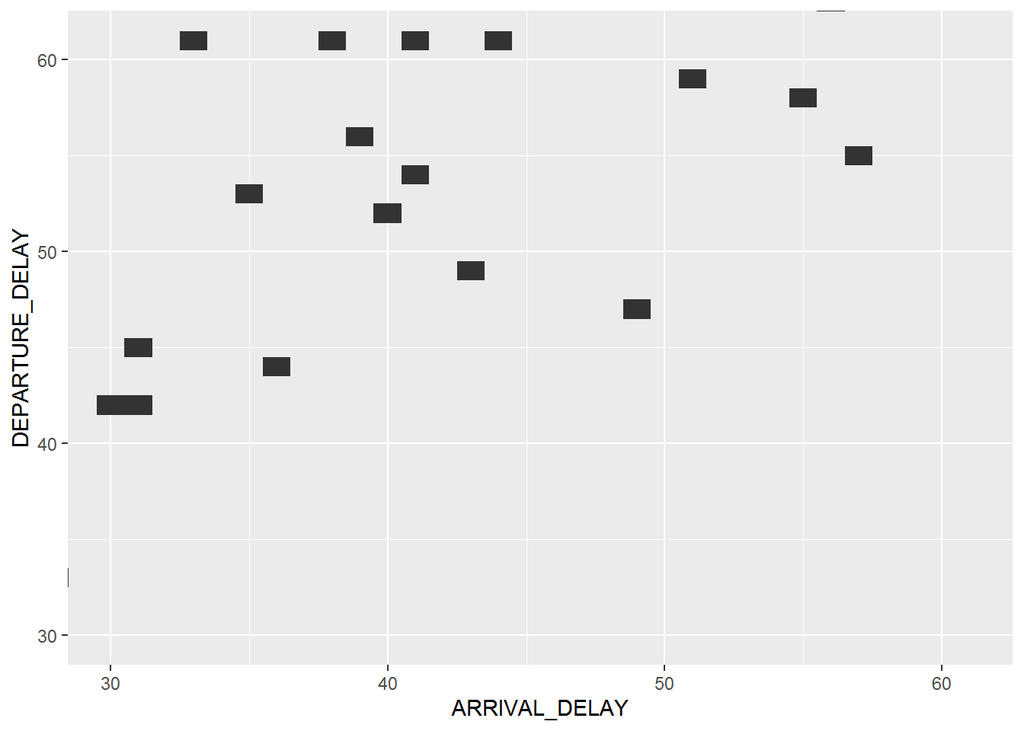

```r
ggplot(subflts) + geom_tile(aes(x=ARRIVAL_DELAY, y=DEPARTURE_DELAY)) + coord_cartesian(xlim=c(30, 61), ylim=c(30,61))
```

```r
#
# ggplot(subflts) + geom_tile(aes(x=DEPARTURE_DELAY, y=ARRIVAL_DELAY)) + coord_cartesian(xlim=c(30, 60), ylim=c(30,65))

# ggplot(subflts) +
#     geom_tile(aes(x=DEPARTURE_DELAY, y=ARRIVAL_DELAY)) +
#   coord_cartesian(xlim=c(29,61),ylim=c(29,61))
```

#Q7 You are creating the visualization below using the following code involving multiple geom layers.

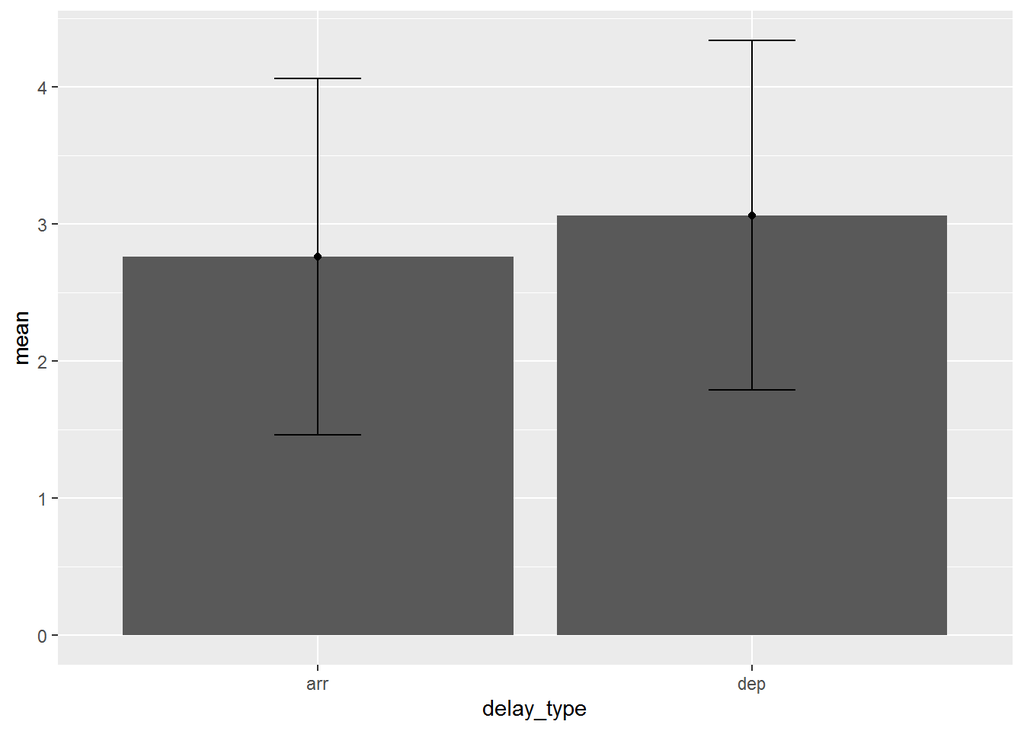

```r
subflts %>% filter(DEPARTURE_DELAY>0 & ARRIVAL_DELAY>0) %>%
  summarize(depmean=mean(log(DEPARTURE_DELAY)), arrmean=mean(log(ARRIVAL_DELAY)),
            depsd=sd(log(DEPARTURE_DELAY)), arrsd=sd(log(ARRIVAL_DELAY))) %>%
  gather(type, value) %>% mutate(delay_type=str_sub(type,1,3), value_type=str_sub(type,4,-1)) %>%
  select(delay_type, value_type, value) %>% spread(value_type, value) %>%
  ggplot() +
  geom_col(aes(x=delay_type, y=mean)) +
geom_point(aes(x=delay_type, y=mean, ymin=mean-sd, ymax=mean+sd)) +
 geom_errorbar(aes(x=delay_type, ymin=mean-sd, ymax=mean+sd), width=.2)
```

#Q8 Which theme was used to create the following visualization with the following code? Fill in the blank in the code.

subflts %>% count(ORIGIN_AIRPORT, DESTINATION_AIRPORT) %>% ggplot() + geom_tile(aes(x=ORIGIN_AIRPORT, y=DESTINATION_AIRPORT, fill=n)) + ###BLANK###()

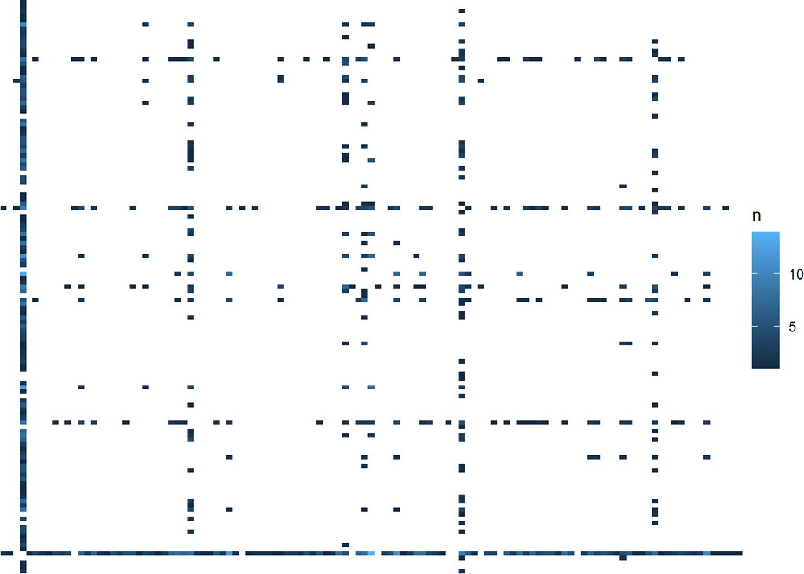

```r
subflts %>% count(ORIGIN_AIRPORT, DESTINATION_AIRPORT) %>%
  ggplot() + geom_tile(aes(x=ORIGIN_AIRPORT, y=DESTINATION_AIRPORT, fill=n)) +           theme_void()#theme_bw()
```